# Modelo CAPM

3-3-2022

Modelo CAPM def.

$R_j-R_f=\alpha+\beta E[R_M-R_F]$

Para estimar esta ecuación necesitamos tres cosas: IPC, el activo y la tasa libre de riesgo

El IPC y el activo los puedo bajar de yahoo finanzas, pero la tasa CETE NO.

Lo usual es calcular el beta del modelo CAPM usando los ultimos 5 años de informacion

```r
datos <- new.env()
clave <- 'GFNORTEO.MX'
getSymbols(clave,from='2017-01-01',to=today(),env=datos)
```

[output not shown]

```
## [1] "GFNORTEO.MX"
```

```r
getSymbols('^MXX',from='2017-01-01',to=today(),env=datos)
```

```
## [1] "^MXX"
```

Definir quien es el objeto y quien es el mercado

Activo

```r
precio_a <- datos[[clave]][,6]
precio_a_m <-to.monthly(precio_a)[,4]
rend_m_a <- monthlyReturn(precio_a_m)[-1,]
names(rend_m_a) <- clave
```

Mercado

```r
precio_ipc <- datos[['MXX']][,6]
precio_ipc_m <- to.monthly(precio_ipc)[,4]
rend_m_ipc <- monthlyReturn(precio_ipc_m)[-1,]
names(rend_m_ipc) <- 'IPC'
```

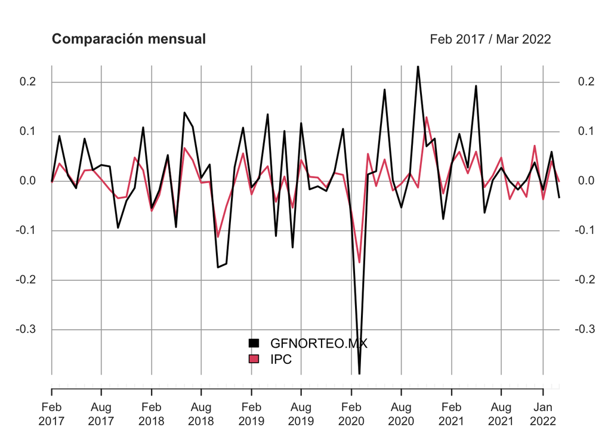

```r
plot(merge.xts(rend_m_a,rend_m_ipc),legend.loc = 'bottom',main = 'Comparación mensual')
```

Ahora necesitamos la tasa libre de riesgo

```r
library(readxl)
Rf <- read_excel("Tasa_Cete.xlsx")
```

```r
Rf <- subset(Rf,Rf$Fecha>='2017-01-01')
Rf$SF43936 <- Rf$SF43936/100/12
```

```r
Rf <- as.xts(Rf$SF43936,order.by=Rf$Fecha)
Rf <- to.monthly(Rf)
```

```r
Rf <- Rf[,4]
Rf <- Rf[-1,]
```

ya tengo mis datos acomodados, para efectuar mi regresión lineal, y calcular los parametros que nececito

Rj será el exceso de rendimiento de mi activo con relacion a la tasa libre de riesgo.

Rm será el exceso de rendimiento del mercado con relacón a la tasa libre de riesgo.

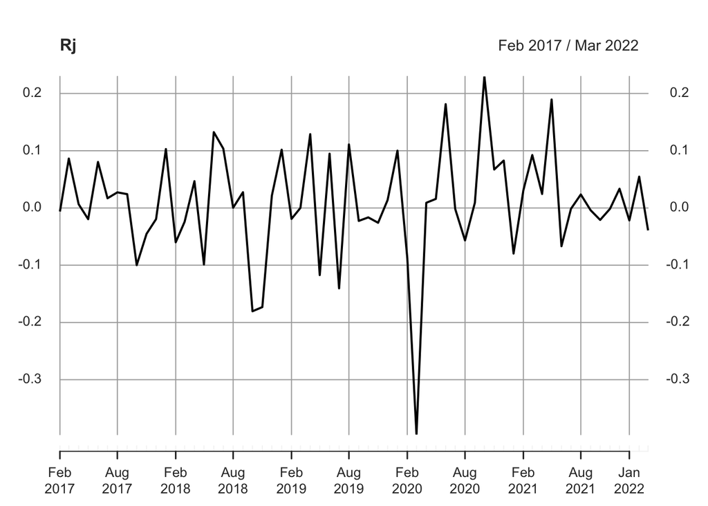

```r
Rj <- Return.excess(rend_m_a,Rf)
plot(Rj)
```

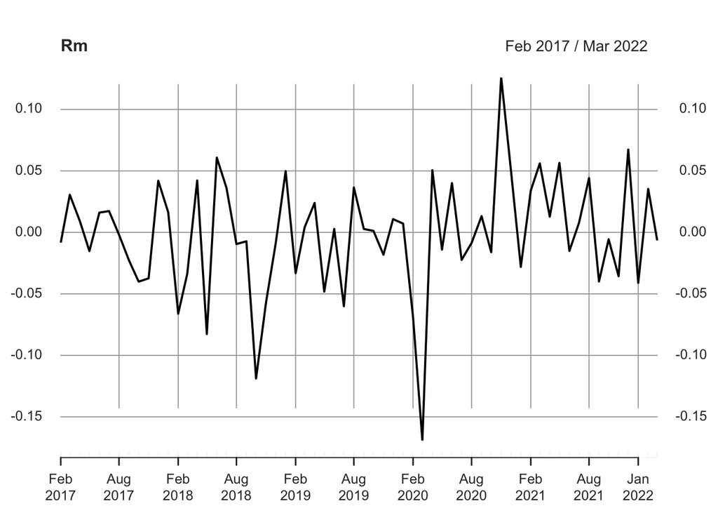

```r
Rm <- Return.excess(rend_m_ipc,Rf)
plot(Rm)
```

```r
CAPM <- lm(Rj~Rm) #alt+ñ=~
```

RC representa el R-cuadrado de la regresión que significa el porcentaje de cambios explicados en la variable dependiente que son consecuencia de la independiente. En términos de la regresión que estamos haciendo RC es el % del riesgo sistemático.

Sigma-e representa a la desviación estándar de epsilon; es decir, que describe a todo ello que no puede expresar el exceso de rendimiento.

```r
Beta <- CAPM$coefficients[2]
Beta
```

```
##       Rm
## 1.602659
```

```r
Alpha <-CAPM$coefficients[1]
Alpha
```

```
## (Intercept)
##  0.01037972
```

```r
RC <- 0.6076
```

```r
sigma_e <- -0.0609
```

Sigma_ e representa la desviacion estandar de todo aquello que se incluye en el excedente del rendimiento del activo y que no se relaciona con el rendimiento del mercado respecto a la tasa libre de riesgo.

```r
RT <- (sigma_e)^2/(1-RC)*100
RT
```

```
## [1] 0.9451606
```

Esto significa que el riesgo total de mi activo es de .9451%

Sabemos que el riesgo se divide en sistematico y no sistematico

```r
Riesgo_NS <- sigma_e^2*100
Riesgo_NS
```

```
## [1] 0.370881
```

Riesgo del sistema

```r
Riesgo_S <- RT-Riesgo_NS
Riesgo_S
```

```
## [1] 0.5742796
```

Si sacamos porporciones de Riesgo, tenemos lo siguiente

```r
Riesgo_S/RT
```

```
## [1] 0.6076
```

```r
Riesgo_NS/RT
```

```
## [1] 0.3924
```

En una tabla:

```r
library(tidyverse)
CAPM <- tibble('Riesgo Total'=paste(format(RT,digits=4),'%'),
               'Riesgo Sistematico'=paste(format(Riesgo_S,digits=4),'%'),
               'Riesgo No Sistematico'=paste(format(Riesgo_NS,digits=4),'%'),
               '% Riesgo Sistematico'=Riesgo_S/RT*100,
               '% Riesgo No Sistematico'=Riesgo_NS/RT*100,
               'Beta'=Beta,'Alpha'=Alpha)
CAPM
```

```
## # A tibble: 1 × 7
##   `Riesgo Total` `Riesgo Sistematico` `Riesgo No Sistematico` `% Riesgo Sistem…`
##   <chr>          <chr>                <chr>                                <dbl>
## 1 0.9452 %       0.5743 %             0.3709 %                              60.8
## # … with 3 more variables: `% Riesgo No Sistematico` <dbl>, Beta <dbl>,
## #   Alpha <dbl>
```